# STA457 Assignment (Fall 2020)

Aichen Liu & 1003850772

2020-12-03

```r
knitr::opts_chunk$set(echo = TRUE)
library(tidyverse)
library(lubridate)
library(xts)
library(timeSeries)
library(forecast)
```

```r
library(ggplot2)
library(knitr)
library(readxl)
library(MASS)
library(forecast)
library(timeDate)
library(sarima)
library(DT)
library(gridExtra)
library(dynlm)

PreWhiten.arma<- function(x , ar = NULL, ma = 0){
        if(is.null(ar) && is.null(ma)) print("both ar and ma coefficients are empty!")
        pwData = numeric(0)
        m = as(modelCoef(new("ArmaModel", ar = ar, ma = ma)), "list")
        eps = numeric(length(x))
        pwData = xarmaFilter(m, x =x, eps = eps, whiten = TRUE)
        pwData[!is.na(pwData)]
}
PreWhiten.ar<- function(x , ar = NULL){
        if(is.null(ar)) print(" autoregressive coefficients are empty!")
        pwData = numeric(0)
        pwData = filter(x, c(1, -ar),method=c("convo"),sides=1)
        pwData[!is.na(pwData)]
}

LBTest<- function(res, nPQ = 0, m = 24, ifPlot = FALSE){
        stopifnot(nPQ >= 0, m >= 1, m > nPQ)
        n <- length(res)
        lags <- 1:m
        df <- (nPQ+1):m
        ra <- (acf(res, lag.max = m, plot = FALSE)$acf)[-1]
        QQ <- n * (n + 2) * cumsum((ra^2)/(n - (1:m)))[df]

        pv <- 1 - pchisq(QQ, df)
        QQ <- round(QQ, 2)
        a <- matrix(c(df, QQ, pv), ncol = 3)
        dimnames(a) <- list(rep("", length(QQ)), c("m", "Qm", "pvalue"))
        if(ifPlot){
                plot(x = a[,1],y = a[,3],
                     ylim = c(0,1), pch = 15, col = "lightblue",
                     ylab = "p-value", xlab = "m",
                     main = "Ljung-Box portmanteau test")
                abline(h =0.05, col =2)
                abline(h =0.01, col =4)
                grid()
        }else {
                a
        }
}
```

#### Calculate the changes of real GDP using the following R codes.

```r
CL = ts(read.csv("DRCLACBS.csv")[,2],frequency = 4, end = c(2020,2))
dat = read.csv("GDPC1.csv")
RGDP = ts(diff(dat[,2])/100,frequency = 4, end = c(2020,3))
```

#### Use the data between 1987 Q1 and 2018 Q3 to study the relationship between the changes of real GDP and delinquency rates.

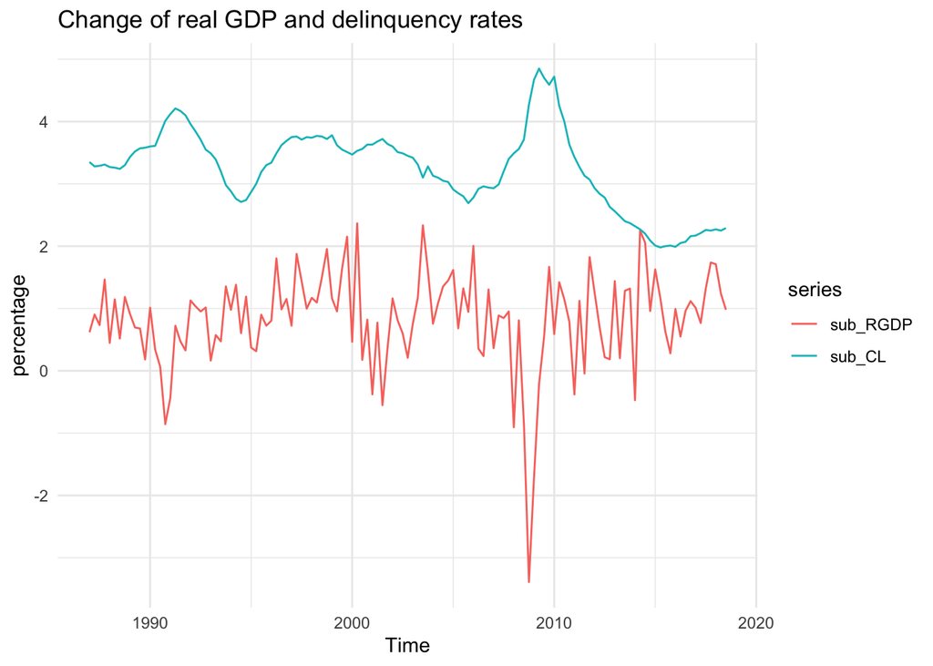

```r
sub_RGDP = window(RGDP, start = c(1987, 1), end = c(2018, 3))
sub_CL= window(CL, start = c(1987, 1), end = c(2018, 3))



x=cbind(sub_RGDP, sub_CL)
autoplot(x) + ggtitle("Change of real GDP and delinquency rates") +
xlab("Time")+ylab("percentage") + theme_minimal()
```

ANS:  
Training sample: start from 1987 Quarter 1, end in 2018 Quarter 3  
Test sample: start from 2018 Quarter 4, end in 2020 Quarter 2

#### Model this relationship using the transfer function noise model.(For simplicity, assume that both delinquency rates and changes of real GDP are stationary.)

1. Conduct `prewhitening` analysis to identify the lead-lag relationship between changes of real GDP and delinquency
   - ARMA model for changes of real GDP and its residual ACF and PACF plots
   - Use cross correlation plot of prewhitened processes to identify transfer function ($\nu_i$)

```r
#' @prewhiten x
#'
mod<-auto.arima(sub_RGDP, max.p = 52, max.q = 52, stationary = TRUE)
mod
```

```
## Series: sub_RGDP
## ARIMA(2,0,0) with non-zero mean
##
## Coefficients:
##          ar1     ar2    mean
##       0.2857  0.1926  0.8235
## s.e.  0.0865  0.0864  0.1200
##
## sigma^2 estimated as 0.5204:  log likelihood=-137.32
## AIC=282.63   AICc=282.96   BIC=294.01
```

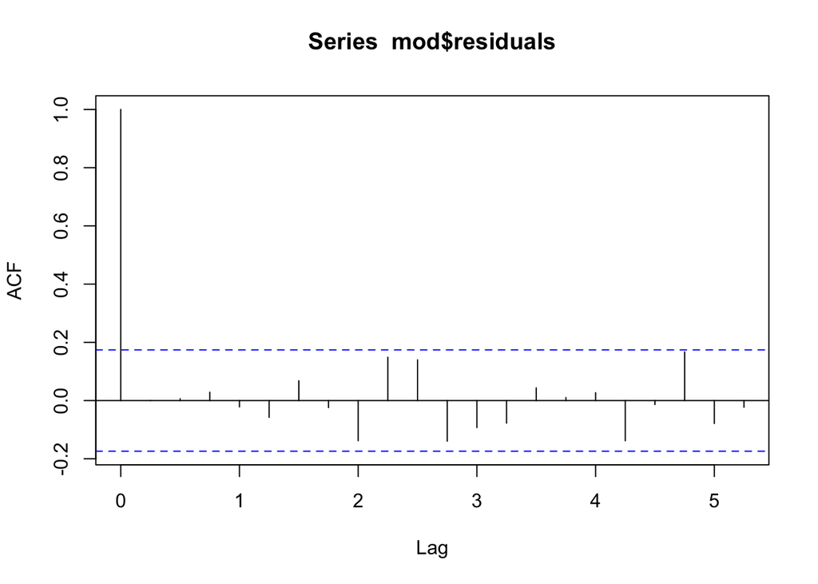

```r
acf(mod$residuals)
```

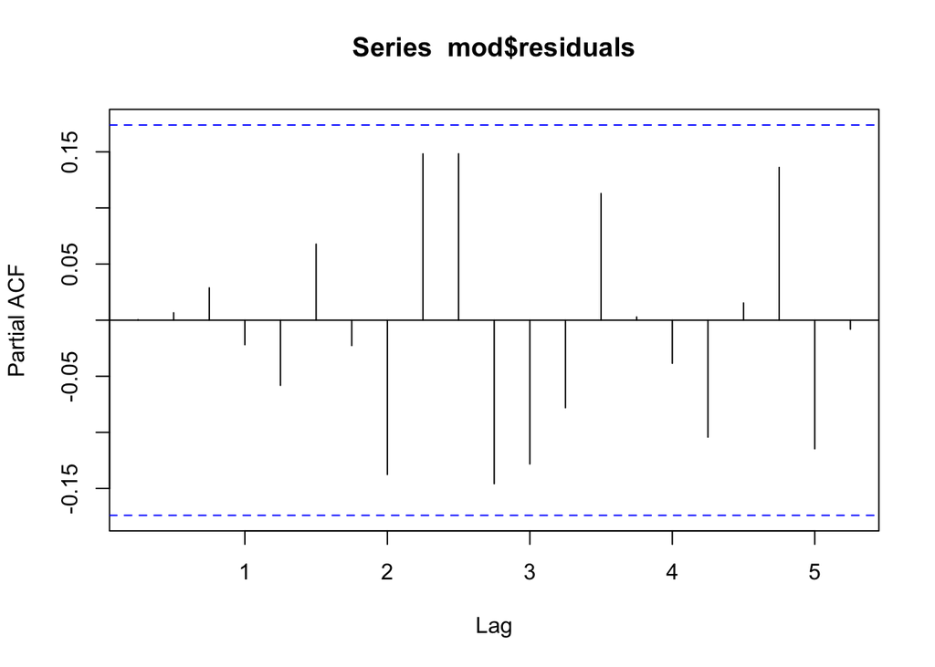

```r
pacf(mod$residuals)
```

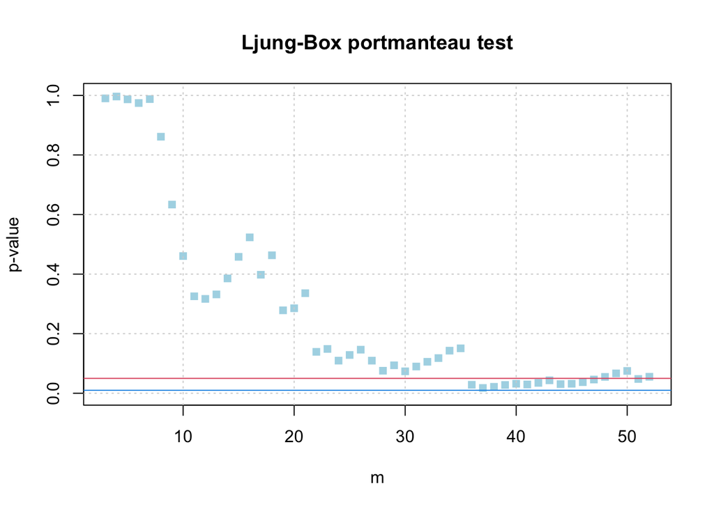

```r
p = mod$arma[1]
q = mod$arma[2]
LBTest(mod$residuals, nPQ = p+q, m = 52, ifPlot = TRUE)
```

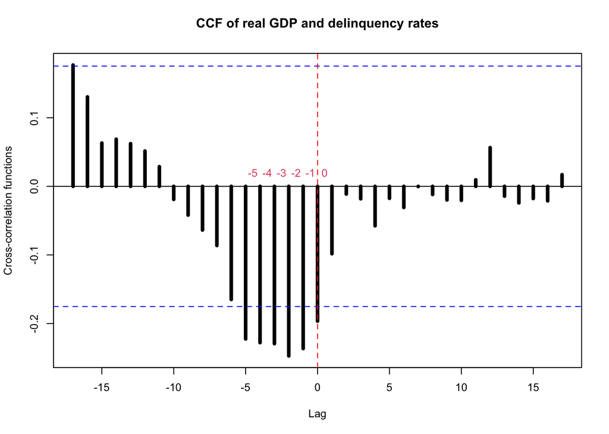

```r
#' @prewhiten y
#'

if(q!=0){
  xf = PreWhiten.arma(sub_RGDP, ar = mod$coef[1:p],
                      ma = mod$coef[(1:q)+p])[-(1:p)]
  yf = PreWhiten.arma(sub_CL, ar = mod$coef[1:p],
                      ma=mod$coef[(1:q)+p])[-(1:p)]
}else{
  xf = PreWhiten.arma(sub_RGDP, ar = mod$coef[1:p],
                      ma = 0)[-(1:p)]
  yf = PreWhiten.arma(sub_CL, ar = mod$coef[1:p],
                      ma=0)[-(1:p)]
}

#' @ccf plot prewhiten x and y
#'
par(cex=0.75)
ccf(c(xf), c(yf), lwd=4, ylab="Cross-correlation functions",main="CCF of real GDP and delinquency rates")
abline(v = 0, col = "red", lwd = 1, lty = "dashed")
text(0.5, 0.02, "0", col=2)
text(-0.5, 0.02, "-1", col=2)
text(-1.5, 0.02, "-2", col = 2)
text(-2.5, 0.02, "-3", col = 2)
text(-3.5, 0.02, "-4", col = 2)
text(-4.5, 0.02, "-5", col = 2)
```

```r
#' @fit Equation (1)
#'
data <- ts.intersect(CL, RGDP, lag(RGDP, -1), lag(RGDP, -2), lag(RGDP, -3), lag(RGDP, -4), lag(RGDP,
-5))
colnames(data) <- c("CL", "RGDP", "RGDP_1", "RGDP_2", "RGDP_3", "RGDP_4", "RGDP_5")
sub_data = window(data, start = c(1987, 1), end = c(2018, 3))
lm = lm(CL ~ RGDP + RGDP_1 + RGDP_2 + RGDP_3 + RGDP_4 + RGDP_5, data = sub_data)
summary(lm)
```

```
##
## Call:
## lm(formula = CL ~ RGDP + RGDP_1 + RGDP_2 + RGDP_3 + RGDP_4 +
##     RGDP_5, data = sub_data)
##
## Residuals:
##      Min       1Q   Median       3Q      Max
## -1.18072 -0.25376  0.06047  0.33032  0.97158
##
## Coefficients:
##             Estimate Std. Error t value Pr(>|t|)
## (Intercept)  3.86949    0.09895  39.106   <2e-16 ***
## RGDP        -0.12977    0.06896  -1.882   0.0623 .
## RGDP_1      -0.13089    0.07163  -1.827   0.0701 .
## RGDP_2      -0.11823    0.07290  -1.622   0.1074
## RGDP_3      -0.10950    0.07299  -1.500   0.1362
## RGDP_4      -0.13460    0.07185  -1.873   0.0635 .
## RGDP_5      -0.16141    0.06939  -2.326   0.0217 *
## ---
## Signif. codes:  0 '***' 0.001 '**' 0.01 '*' 0.05 '.' 0.1 ' ' 1
##
## Residual standard error: 0.5531 on 120 degrees of freedom
## Multiple R-squared:  0.3156, Adjusted R-squared:  0.2814
## F-statistic: 9.224 on 6 and 120 DF,  p-value: 2.651e-08
```

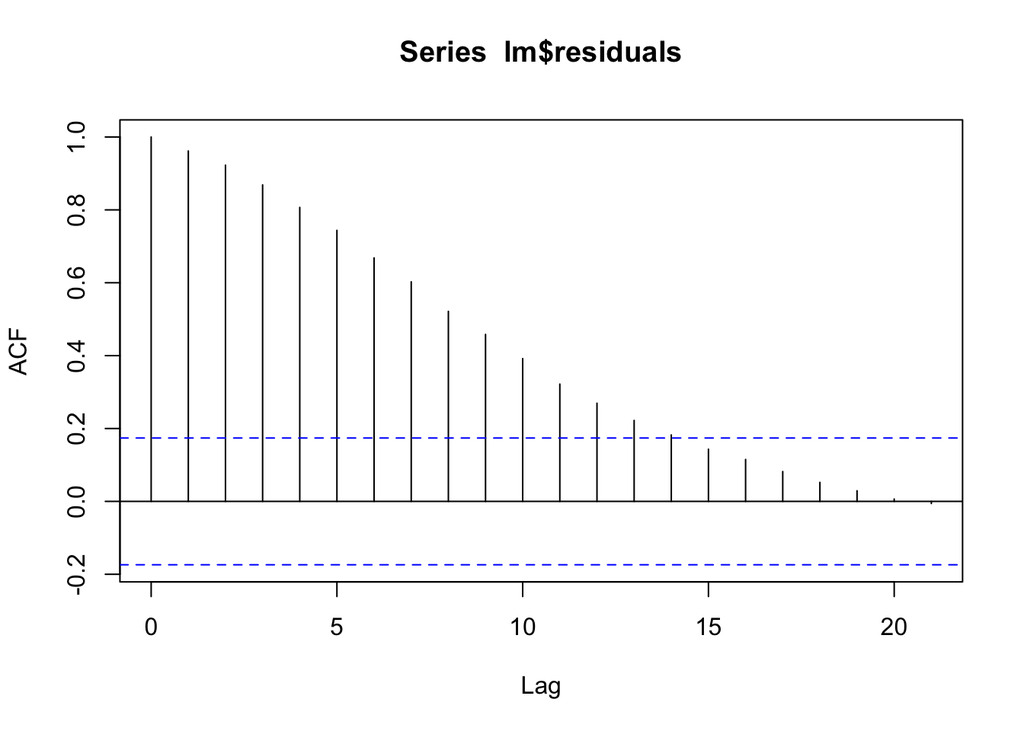

```r
#' @plot residual ACF and PACF of the above regression
#'

acf(lm$residuals)
```

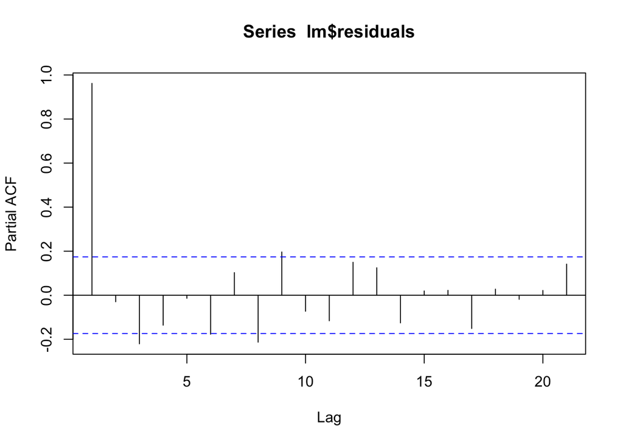

```r
pacf(lm$residuals)
```

ANS:
From the above question, we know that we need to include 5 lags in this regression. Firstly we synchronize a new data set that include the five lags and split to into a traing set called sub_data and a testing set called test_data. Then we fit the regression. The resulting p-values for the Ljung-Box Portmanteau test for the residuals of the linear model is all less than 0.05 confidence level. This linear model is not adequate.
3. Fit a transfer function noise model using the rational distributed lag function, i.e.
$$y_t = \frac{\delta(B)}{\omega(B)}x_t+n_t,~~~(2)$$
where $\delta(B)$ and $\omega(B)$ are polynomials in the backward shift operator $B$, and $n_t$ follows an ARMA process. Write down the mathematical representation of the fitted model.

```r
#' @fit Equation (2) and show the fitted model
#'
mod.tfn = auto.arima(sub_data[, 1], xreg =sub_data[, -1], stationary = TRUE)
round(coef(mod.tfn),2)
```

```
##       ar1       ar2       ma1       ma2      sar1      sar2 intercept      RGDP
##      1.89     -0.90     -0.56      0.04     -0.15     -0.38      3.46     -0.05
##    RGDP_1    RGDP_2    RGDP_3    RGDP_4    RGDP_5
##     -0.06     -0.05     -0.03     -0.05     -0.04
```

- **Write down the mathematical equation of your fitted model**

ANS:
SARIMA(2,0,2)(2,0,0)[4]
$$y_t=226.14-\frac{(0.05+0.06B+0.05B^2+0.03B^3+0.05B^4+0.04B^5)}{(1+0.15B^4+0.38B^8)(1-1.89B+0.9B^2)}X_t+\frac{(1-0.56B+0.04B^2)}{(1+0.15B^4+0.38B^8)(1-1.89B+0.9B^2)}a_t$$
$$where\frac{3.46}{(1+0.15+0.38)(1-1.89+0.9)}\approx226.14$$
I personally think we need to include the seasonal component.
4. Conduct the model adequacy tests (diagnostics) on the above models and conclude your inference.

- Linear Regression Model adequacy tests

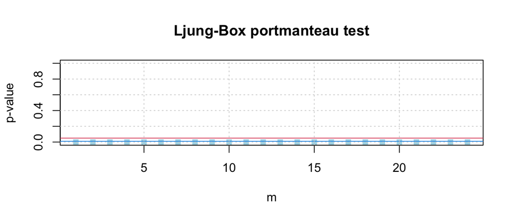

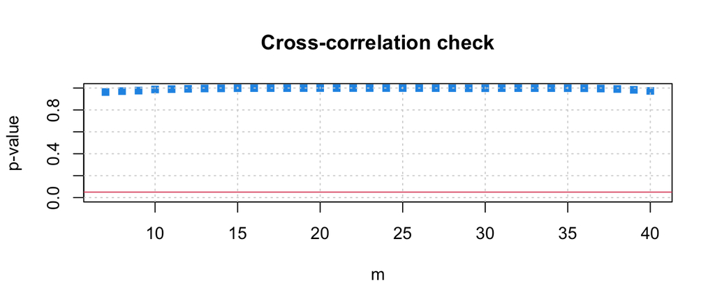

- TFN Model adequacy tests

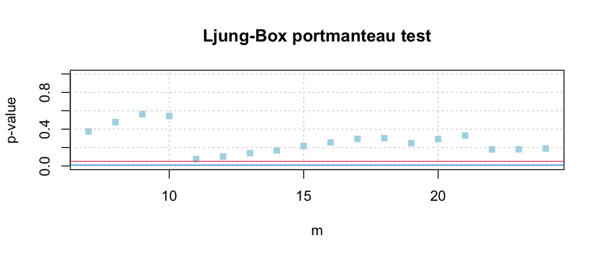

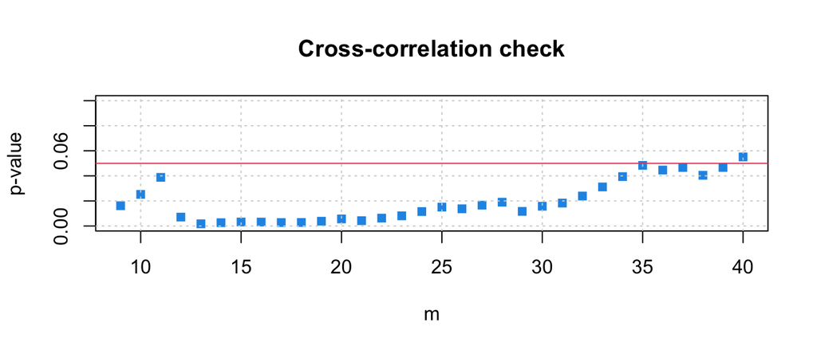

#### Conduct the out of sample forecasts of the above fitted models using the remaining observations. Calculate the forecast performance using Mean squared error (MSE), Mean absolute error (MAE), and Mean absolute percentage error (MAPE):

$$MSE = \sqrt \frac{\sum_{i=1}^L (y_{t+i}-\hat y_t(i))^2}{L}$$
$$MAE = \frac{\sum_{i=1}^L \left|y_{t+i}-\hat y_t(i)\right|}{L}$$
$$MAPE = \frac{1}{L}\sum_{i=1}^L \left|1-\frac{\hat y_t(i)}{y_{t+i}}\right|,$$

#### where $\hat y_t(i)$ denotes the forecast at origin $t$ with lead time $i$

```r
#' @forecast using linear regression
#'
test_data=window(data,start=c(2018,4))
test_data_lm = as.data.frame(test_data)
linear_pred = forecast(lm, newdata = test_data_lm[,-1])



#' @calculate MSE, MAE, MAPE
#'
MSE_lm = mean((test_data_lm$CL-linear_pred$mean)^2)%>%sqrt()
MAE_lm = mean(abs(test_data_lm$CL-linear_pred$mean))
MAPE_lm = mean(abs(1-linear_pred$mean/test_data_lm$CL))*100
res1 = cbind (MSE_lm,MAE_lm,MAPE_lm)
colnames(res1) = c("MSE","MAE","MAPE")
kable(res1, digits = 2, caption = "Out-of-sample Forecasts Accuracy Using LM")
```

Out-of-sample Forecasts Accuracy Using LM

| MSE | MAE | MAPE |
| --- | --- | --- |
| 1.6 | 1.15 | 53.18 |

```r
#' @forecast using tfn
#'

tfn_pred = forecast(mod.tfn,xreg = test_data[,-1])

#' @calculate MSE, MAE, MAPE
#'
MSE_tfn = mean((test_data_lm$CL-tfn_pred$mean)^2)%>%sqrt()
MAE_tfn = mean(abs(test_data_lm$CL-tfn_pred$mean))
MAPE_tfn = mean(abs(1-tfn_pred$mean/test_data_lm$CL))*100
res = cbind (MSE_tfn,MAE_tfn,MAPE_tfn)
colnames(res) = c("MSE","MAE","MAPE")
kable(res, digits = 2, caption = "Out-of-sample Forecasts Accuracy Using TFN")
```

Out-of-sample Forecasts Accuracy Using TFN

| MSE | MAE | MAPE |
| --- | --- | --- |
| 0.78 | 0.45 | 21.25 |

ANS:  
RMSE is the standard deviation of the residuals, lower values of RMSE indicate better fit. The RMSE for the linear model and the TFN model are 1.6 and 0.78 respectively. Therefore TFN model has better fit. MAE measures the average of the errors in a set of forecasts regardless of the direction, the lower the values the smaller the error. The MAE for the two models are 1.15 and 0.45 respectively, therefore TFN model has less error. The smaller the MAPE the better the forecast, the MAPE for the two models are 53.18 and 21.25 respectively, therefore TFN model makes better forecasts. To sum up, the TFN model is better than the Linear model.

#### Conduct the same out of sample forecasts soley on $y_t$ using an ARIMA model. Compare and discuss its peformance metrics with the TFN model.

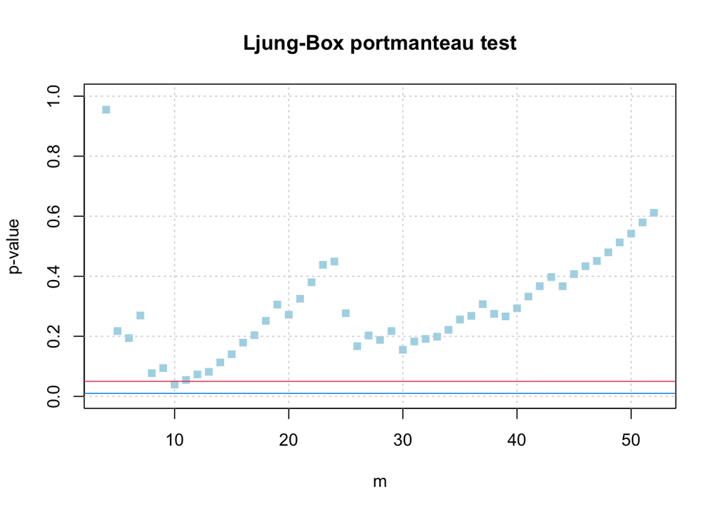

```r
#' @forecate using auto.arima
#'
arima=auto.arima(sub_data[,1],stationary = TRUE)
LBTest(arima$residuals,nPQ =3,m=52,ifPlot = TRUE)
```

```r
h = length(test_data[,1])
arima_pred = forecast(arima,h = h)


#' @calculate MSE, MAE, MAPE
#'

MSE_arima = mean((test_data_lm$CL-arima_pred$mean)^2)%>%sqrt()
MAE_arima = mean(abs(test_data_lm$CL-arima_pred$mean))
MAPE_arima = mean(abs(1-arima_pred$mean/test_data_lm$CL))*100
res2 = cbind (MSE_arima,MAE_arima,MAPE_arima)
res22 = rbind(res2,res)
colnames(res22) = c("MSE","MAE","MAPE")
rownames(res22) = c("ARIMA Model","TFN Model")
kable(res22, digits = 2, caption = "Out-of-sample Forecasts Accuracy Using ARIMA and TFN")
```

Out-of-sample Forecasts Accuracy Using ARIMA and TFN

|  | MSE | MAE | MAPE |
| --- | --- | --- | --- |
| ARIMA Model | 0.38 | 0.28 | 12.69 |
| TFN Model | 0.78 | 0.45 | 21.25 |

#### Conduct the same out of sample forecast analysis using forecast combination of the fitted TFN model and ARIMA model (equal weight and MSE weighting). Compare its forecast metrics with those in the previous two questions

- *Forecast combination:*
  The combined forecaster $\hat f_t(i)$ may be given by
  $$\hat f_t(i) = w_a ~ \hat y_t^{(a)}(i)+w_b~ \hat y_t^{(b)}(i),$$
  where the superscripts $(a)$ and $(b)$ stand for transfer function noise model and ARIMA model, respectively. For the equal weight scheme, $w_a = w_b = 0.5$, and for the MSE weighting scheme, its weights is the solution of
  $$\min_{w_a} \sqrt {\sum_{t=1}^n \{y_t -w_a \hat y_t^{(a)}-(1-w_a)\hat y_t^{(b)}\}^2},$$
  where $w_a, w_b \in[0,1]$, $w_a+w_b=1$, and $\hat y_t^{(a)}$ denote the fitted value at time $t$ in the training sample and $n$ is the series length.

```r
#' @calculate MSE, MAE, MAPE for the equal weight forecast
#'
equ_weight_pred= 0.5*tfn_pred$mean + 0.5*arima_pred$mean

MSE_equ_weight = mean((test_data_lm$CL-equ_weight_pred)^2)%>%sqrt()
MAE_equ_weight = mean(abs(test_data_lm$CL-equ_weight_pred))
MAPE_equ_weight = mean(abs(1-equ_weight_pred/test_data_lm$CL))*100
res3 = cbind (MSE_equ_weight,MAE_equ_weight,MAPE_equ_weight)
res33 = rbind(res3,res22,res1)
colnames(res33) = c("MSE","MAE","MAPE")
rownames(res33) = c("Combined_equalWeight","ARIMA Model","TFN Model","LM")
kable(res33, digits = 2, caption = "Out-of-sample Forecasts Accuracy")
```

Out-of-sample Forecasts Accuracy

|  | MSE | MAE | MAPE |
| --- | --- | --- | --- |
| Combined_equalWeight | 0.57 | 0.36 | 16.97 |
| ARIMA Model | 0.38 | 0.28 | 12.69 |
| TFN Model | 0.78 | 0.45 | 21.25 |
| LM | 1.60 | 1.15 | 53.18 |

```r
#' @calculate MSE scheme weight
#'

f = function(w){sqrt(sum((sub_data[,1]-w*mod.tfn$fitted - (1-w)*arima$fitted)^2))}
w = optimize(f,c(0,1))$minimum
weighted_pred= w*tfn_pred$mean + (1-w)*arima_pred$mean

#' @calculate MSE, MAE, MAPE for the above combination forecast
#'

MSE_weighted = mean((test_data_lm$CL-weighted_pred)^2)%>%sqrt()
MAE_weighted = mean(abs(test_data_lm$CL-weighted_pred))
MAPE_weighted = mean(abs(1-weighted_pred/test_data_lm$CL))*100

res4 = cbind (MSE_weighted,MAE_weighted,MAPE_weighted)
res44 = rbind(res4,res33)
colnames(res44) = c("MSE","MAE","MAPE")
rownames(res44) = c("Combined_Weighted","Combined_equalWeight","ARIMA Model","TFN Model","LM")
kable(res44, digits = 2, caption = "Out-of-sample Forecasts Accuracy")
```

Out-of-sample Forecasts Accuracy

|  | MSE | MAE | MAPE |
| --- | --- | --- | --- |
| Combined_Weighted | 0.76 | 0.44 | 21.00 |
| Combined_equalWeight | 0.57 | 0.36 | 16.97 |
| ARIMA Model | 0.38 | 0.28 | 12.69 |
| TFN Model | 0.78 | 0.45 | 21.25 |
| LM | 1.60 | 1.15 | 53.18 |

ANS:  
The ARIMA Model has the lowest RMSE, MAE and MAPE. Therefore, the ARIMA model has a better fit of the data, and smaller forecasting error. Compare with the other models, the ARIMA model is the best.

- **Reference:** William W.S. Wei (2006), *Time Series Analysis–Univariate and Multivariate Methods*, Second Edition. (Chapter 14)